# Airbnb Pricing in Shanghai / China

Data Analysis 3 - Assignment 2

Ersan Kucukoglu

10th February 2022

## Introduction

This assignment focuses on a single location - Shanghai, China - and seeks to estimate AirBnB rental costs per night for a firm renting small and mid-size flats (2-6 guests) to assist them in pricing their properties that are not yet on the market.

## Data

The used dataset was downloaded from [insideairbnb.com](http://insideairbnb.com/get-the-data.html) which is a site collecting data on AirBnB listings in numerous cities. As mentioned above the dataset contains data on listings in Shanghai and was last updated on 24th December 2021.

### Cleaning

Some data cleaning was required to make the dataset viable for prediction applications. There were 29165 observations and 74 variables in the raw dataset. Some of these variables, such as urls and textual descriptions, were removed since the data contained in them could not be utilised by the deployed prediction models. Data types have to be adjusted since some numeric and date variables were saved as characters. There was another one variable, amenities, which recorded various listing attributes and extras in a list style. This variable was initially divided into independent dummy variables, and then comparable ones, such as wifi with varied speeds, grouped together.At the end of the operation, the grouping produced 9 dummy variables. The full dataset was filtered to only contain listings that are complete apartments and can accommodate 2-6 guests, and factors were created from qualitative variables with multiple categories. This implies that the data contains three categories of apartments: rental units, lofts, and serviced apartments.

## Exploratory Data Analysis

After cleaning, I double-checked the qualities of the variables I intend to use in the prediction models. This necessitated reviewing descriptive data, its distribution, and, in the case of explanatory factors, investigating their association to the target variable - the price per person per night.

Descriptive statistics of target variable

| Variable | Mean | 5th Percentile | Median | 95th Percentile | Std | Min | Max | N |
| --- | --- | --- | --- | --- | --- | --- | --- | --- |
| Price | 686.06 | 123.2 | 398 | 1299 | 2547.18 | 0 | 75771 | 9525 |

After removing the data, I created a histogram for the price variable, which is shown below. Based on the graph, we can state that its distribution is skewed with a large right tail; nevertheless, for simplicity of interpretation, I choose to utilize its levels rather than its logs.

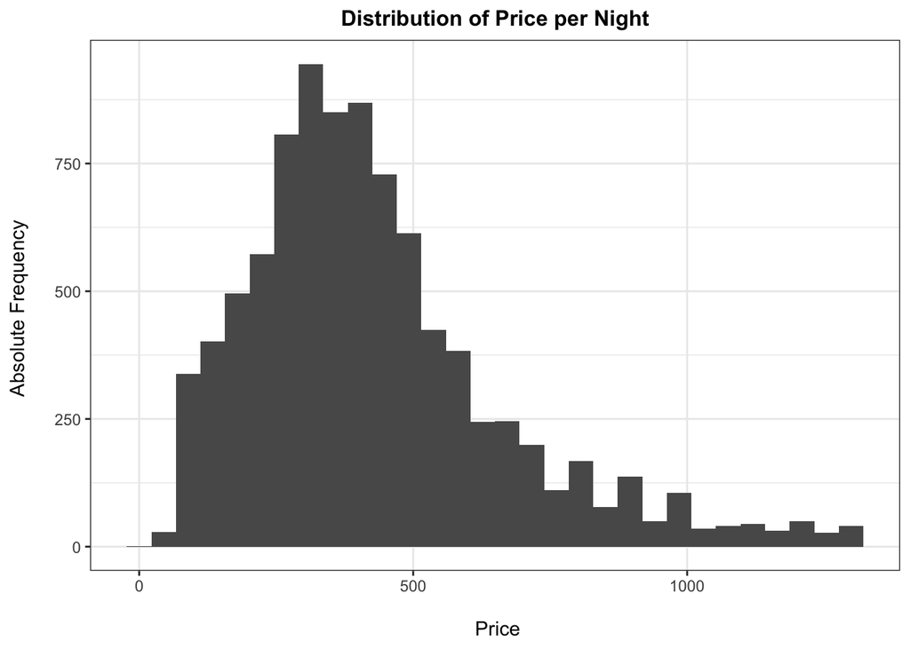

### Feature engineering

Having decided about the functional form of the target variable I inspected the explanatory variables and their relationship with the target variable. Besides deciding on grouping of factor variables functional forms also had to be decided because two of the used prediction models were OLS and OLS with LASSO for which this step is necessary.

First, I inspected the two factor variables: property type and neighbourhood. The prices conditional on property type can be seen in the chart below. Since there are differences between the three categories in conditional means as well as standard deviation I decided to keep all three.

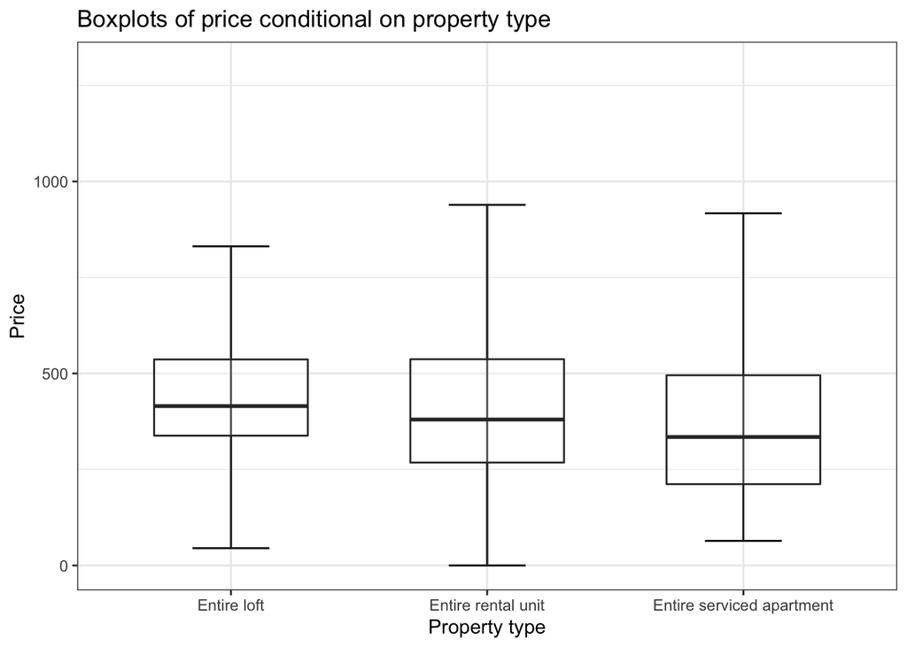

I examined the dummies after the categorical variables. There are 13 in all, 9 of which were formed by separating and grouping the amenities variable, 3 of which are related to host features such as if their identity is confirmed, and 1 of which is linked to the apartment and tells whether it may be booked instantly. I calculated the conditional mean price for each dummy and came to the conclusion that my assumptions were correct in the sense that an apartment with more extras priced more in general.

The number of guests the apartment can accommodate is likely one of the most crucial numerical variables in determining the pricing. The table below shows how the price varies with the number of guests. Despite the wide standard deviation, the prices of apartments that can accommodate more people tend to be higher, and because the association looks linear, I agreed to keep this variable as it is and treat is as a continuous one.

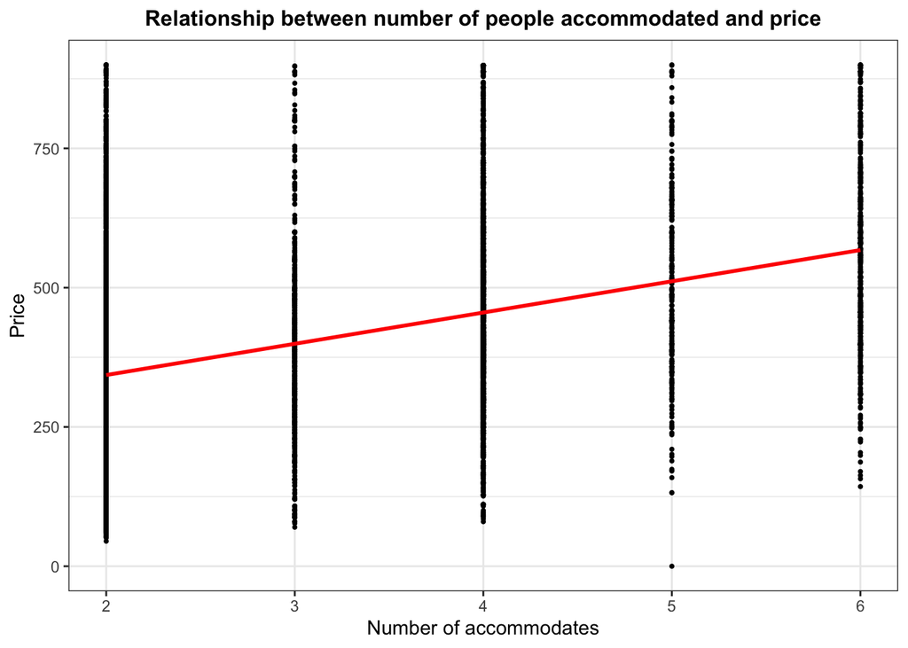

I repeated this process for all the other numeric variables as well. If one variable only had a few values then I calculated the conditional mean of price for those and for every variable I examined its relationship with price either by a loess regression or a very simple OLS which contained price as the outcome variable and the variable in question plus its transformed versions. The loess regression showed the pattern of association between the target and the explanatory variable while the OLS helped to confirm if my assumption about the functional form was right.

In the charts below I highlight some of the patterns that I discovered. In the first one we can see that the relationship between the number of beds and price is nonlinear, therefore I created a new variable as the square of the number of beds variable so that I can add it to the OLS and LASSO models later on.

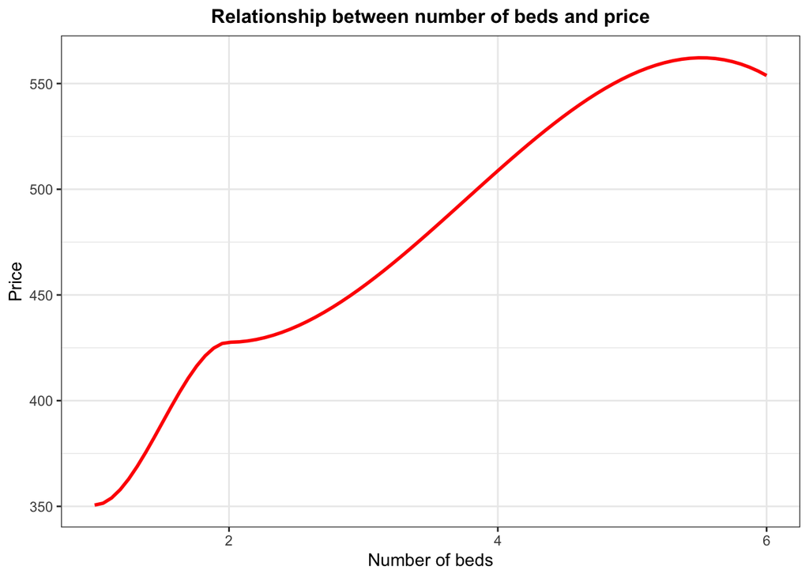

Based on the histogram below I could conlcude that the number of reviews has a very skewed distribution therefore I added its log to the dataset and checked whether it gave a better result for the OLS that I ran using price and number of reviews. Since it did produce a better result I decided to use the log transformed version of this variable in the OLS and LASSO models.

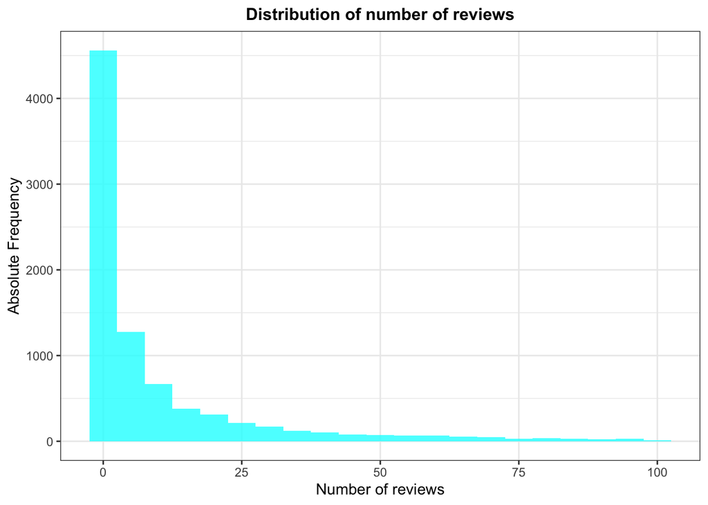

I also checked the number of missing values for each of the variables. Fortunately there were no missing values in the target variable so I did not lose observations because of them. As for the explanatory variables I applied the following method: If the missing values could be substituted in any way by utilizing the values of another variable, I did so. For example, when the number of beds for an apartment was missing, I substituted it with the number of persons accommodated variable because they are likely to be the same. If the variable had less than 10 missing values that I couldn’t impute in the above-mentioned manner, I imputed it using the variable’s median. If the variable had more than 10 missing values but less than 20% of its total value was missing, I performed the same thing as in the second example, plus I added flags to show where I had imputed values.

Lastly, I examined possible interactions between the property type factor variable and all the dummy variables by using plots. I created two lists of interactions: one for OLS and one for LASSO. In the one for OLS I only included those ones where the differences between the different categories of variables were indeed very big, whereas in the one for LASSO I included even those where the differences were smaller.

At the end of the label and feature engineering process the dataset contained 9065 observations in total on apartments that can accommodate 2-6 guests.

## Modeling

- OLS
- LASSO
- Random forest.

I proceeded by dividing the data into two parts: a training set and a holdout set. They included 80% and 20% of the observations, respectively. Then I made many lists of variables that I might use for various models. The ones for OLS and LASSO included variable levels as well as modified versions and interactions, whereas random forest just included variable levels. Using five fold cross-validation, I estimated many models with varying sets of variables or tuning parameters depending on the model. I utilized the average RMSE on the test sets as well as the RMSE on the holdout set to select the model with the best performance.

### OLS and LASSO

In total I estimated 3 OLS models with different sets of variables. The first one contained only the levels of variables, the second one contained the levels and the transformed versions, while the last one contained interactions as well.

For LASSO, I estimated two models: one with levels and transformed versions of variables plus a few interactions and one with levels and transformed versions of variables plus all the interactions I previously determined. For the lambda parameter I set the search to be between 0.01 and 1 by 0.05 differences. The value of lambda for the better model was 0.36.

When comparing the coefficients of the OLS and LASSO models, I came to the conclusion that their signs were the same, but those of the LASSO models were much smaller overall.

OLS and LASSO performance

|  | Number of Coefficients | CV RMSE | Holdout RMSE |
| --- | --- | --- | --- |
| OLS 1 | 47 | 151.86 | 146.58 |
| OLS 2 | 55 | 151.38 | 146.45 |
| OLS 3 | 67 | 151.24 | 145.70 |
| LASSO 1 (few interactions) | 65 | 151.04 | 145.68 |
| LASSO 2 (all interactions) | 75 | 150.86 | 145.93 |

Because the LASSO 2 model performed the best, I created the plot below, which displays the actual prices as well as the prices predicted by this model. We can observe that it gives better predictions for cheaper prices and somewhat underestimates prices.

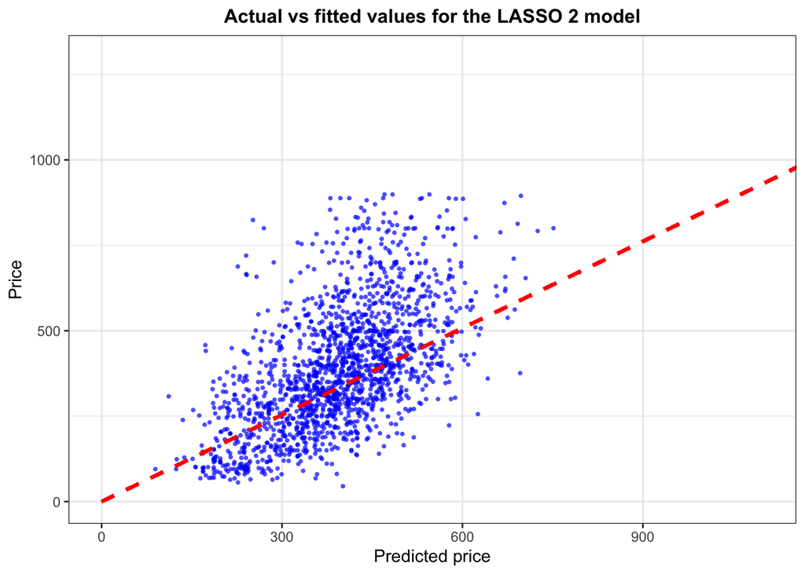

### Random forest

I estimated two random forest models in total using the levels of all variables. The models differ in the parameter sets that determine the number of randomly chosen variables at each split and the minimum number of observations in the terminal nodes for each tree. Following the rule of thumb first I set the number of randomly chosen variables at each split to 6 which is around the square route of all variables. However, as the table below shows both final models produced better results when setting the parameter to a higher number.

Best hyperparameter sets for random forest models

|  | Min. number of variables | Min. node size |
| --- | --- | --- |
| Random forest 1 | 10 | 5 |
| Random forest 2 | 12 | 5 |

Different hyperparameter sets Random forest 2

| Nodes | 8 | 10 | 12 |
| --- | --- | --- | --- |
| 5 | 131.70 | 131.08 | 130.47 |
| 10 | 132.92 | 132.10 | 131.69 |
| 15 | 133.99 | 133.28 | 132.58 |

To be able to decide which model is better I calculated the cross-validated RMSE-s on the test sets. We can see in the table below that Random forest 2 performs better than Random forest 1. But again just like in the case of the OLS and LASSO models the difference between the two models is relatively small.

Performance of random forest models

|  | RMSE |
| --- | --- |
| Random forest 1 | 131.01 |
| Random forest 2 | 130.47 |

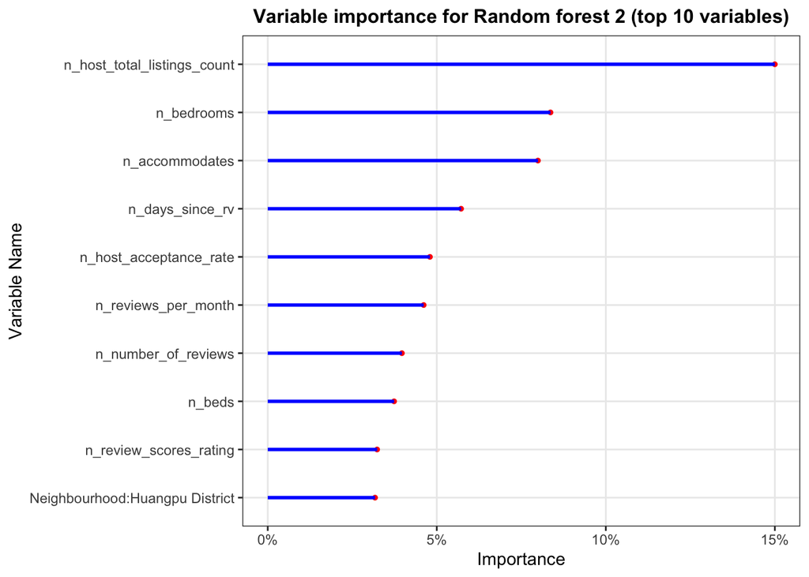

Another method for producing the variable significance plot is to group the various sorts of variables. From the factors I utilized, I created four major groupings. The first is made up of fundamental variables that characterize the apartment’s qualities, the second of which is host information, the third of which is information regarding reviews, and the fourth of which is made up of amenities dummies. The graph below depicts their significance for the Random Forest 2 model. It may be inferred that the host information and fundamental apartment parameters are the most relevant and contribute for around 60-70 percent of the RMSE decrease.

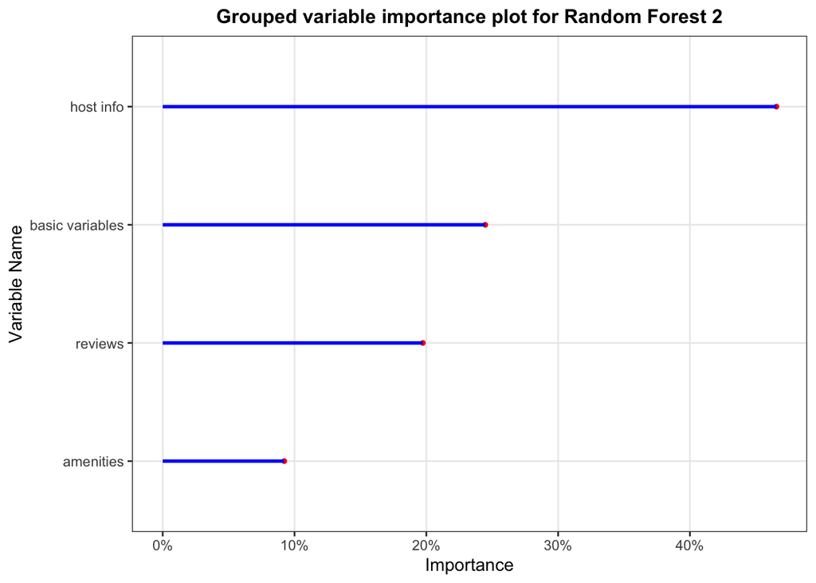

### Model selection

After running different types, I choose the best results from each method. I described their cross-validated RMSEs as well as their RMSEs determined on the holdout set in the table below. According to these data, the random forest model outperformed the LASSO and OLS models. However, the pricing plan I would recommend for the firm would be determined by their choices. If they want to see the relationship between specific explanatory factors and the target variable and have coefficients, I would recommend using either the LASSO model or the OLS because their performance is fairly close. Otherwise, I would suggest using the random forest model since that one has the best prediction performance.

Model performance comparison

|  | CV RMSE | Holdout RMSE |
| --- | --- | --- |
| OLS 3 | 151.24 | 145.70 |
| LASSO (all interactions) | 150.86 | 145.93 |
| Random forest 2 | 130.47 | 123.30 |